# Nearest Neighbor Gaussian Processes (NNGP) based models in Stan

# Results and Discussion

In this section, we will show the results of the simulation study, compare response and latent NNGP models, and provide suggestions on how to use NNGP based models.

## Response NNGP model for simulation study

Response NNGP model is faster and easier to sample from posterior distribution than the latent NNGP models. The following shows the summary table and trace plot of the posterior samples from response NNGP model.

```r
print(samples)
```

```
Inference for Stan model: nngp_response.
3 chains, each with iter=600; warmup=300; thin=1;
post-warmup draws per chain=300, total post-warmup draws=900.

          mean se_mean   sd    2.5%    25%    50%    75%  97.5% n_eff Rhat
beta[1]   0.73    0.02 0.51   -0.24   0.42   0.74   1.07   1.69   436 1.00
beta[2]   5.00    0.00 0.03    4.95   4.99   5.00   5.02   5.06   552 1.01
sigmasq   2.44    0.05 0.78    1.50   1.90   2.25   2.73   4.44   280 1.00
tausq     0.10    0.00 0.03    0.05   0.08   0.10   0.12   0.16   775 1.00
phi       4.49    0.07 1.28    2.12   3.60   4.49   5.35   7.02   373 1.00
lp__    -99.17    0.09 1.68 -103.51 -99.97 -98.85 -97.93 -97.04   345 1.00

Samples were drawn using NUTS(diag_e) at Mon Jun  8 22:07:07 2020.
For each parameter, n_eff is a crude measure of effective sample size,
and Rhat is the potential scale reduction factor on split chains (at
convergence, Rhat=1).
```

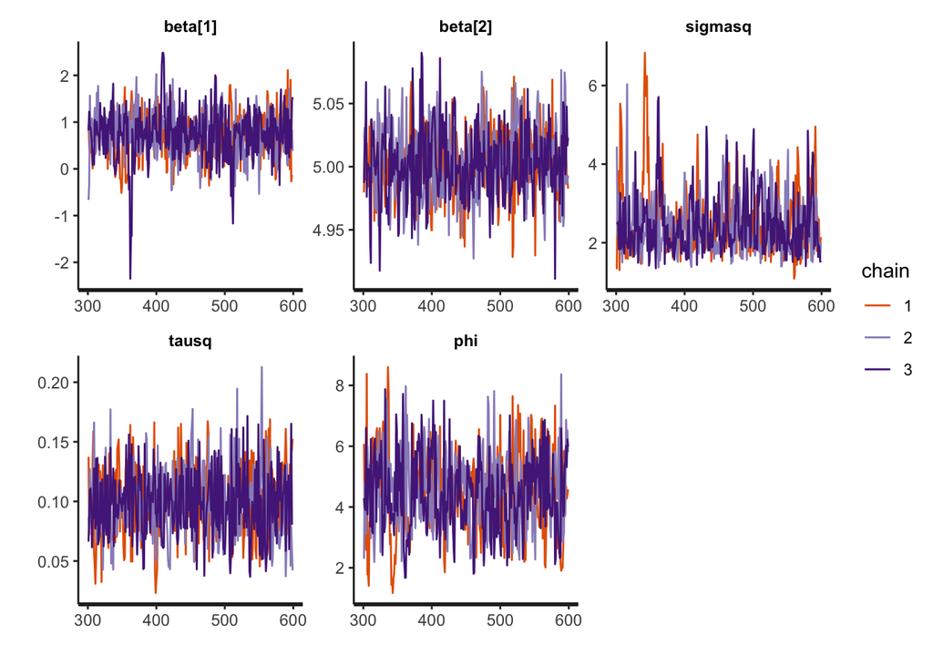

```r
stan_trace(samples)
```

We took the model with marginal GP likelihood as a benchmark for comparison. The comparison of NNGP to regular GP is conducted using plain Stan code for both models. The current NNGP Stan code is a proof of concept showing significant speed-up from NNGP algorithm, and further speed-up could be obtained by writing a built-in function in C++ for NNGP. For the sake of simplicity, we suppress the full code and give the summary table below. Regular GP with exponentiated quadratic covariance function could be coded using built-in cov_exp_quad function, which speeds up computation considerable. The posterior estimates of the parameters from two models are similar, while the running time required for response NNGP model is much less than the basic GP. The efficiency of NNGP will be more obvious when the dataset gets larger.

```r
print(samples_GP)
```

```
Inference for Stan model: GP_marginal.
3 chains, each with iter=600; warmup=300; thin=1;
post-warmup draws per chain=300, total post-warmup draws=900.

          mean se_mean   sd   2.5%    25%    50%    75%  97.5% n_eff Rhat
beta[1]   0.70    0.17 1.10  -1.27   0.21   0.66   1.11   3.65    41 1.08
beta[2]   5.00    0.00 0.03   4.95   4.98   5.00   5.02   5.06   679 1.00
sigmasq   3.34    0.34 2.75   1.53   2.06   2.57   3.47  10.76    65 1.04
tausq     0.10    0.00 0.03   0.05   0.09   0.10   0.12   0.16   615 1.00
phi       3.75    0.14 1.50   0.82   2.72   3.81   4.78   6.66   117 1.02
lp__    -93.26    0.28 2.23 -99.34 -94.20 -92.62 -91.66 -90.70    63 1.04

Samples were drawn using NUTS(diag_e) at Mon Jun  8 22:31:40 2020.
For each parameter, n_eff is a crude measure of effective sample size,
and Rhat is the potential scale reduction factor on split chains (at
convergence, Rhat=1).
```

```r
print(get_elapsed_time(samples))
```

```
         warmup  sample
chain:1 53.6964 34.3206
chain:2 53.3914 35.0666
chain:3 53.0144 39.8883
```

```r
print(get_elapsed_time(samples_GP))
```

```
         warmup  sample
chain:1 668.094 424.926
chain:2 672.109 430.697
chain:3 540.913 461.228
```

## Latent NNGP models for simulation study

The following gives the summary table of posterior samples and trace plots of the MCMC Chains from the latent NNGP model:

```r
print(samples_w, pars = c("beta", "sigmasq", "tausq", "phi", "w[1]", "w[2]",
                          "w[3]", "w[4]"))
```

```
Inference for Stan model: nngp_latent.
3 chains, each with iter=600; warmup=300; thin=1;
post-warmup draws per chain=300, total post-warmup draws=900.

         mean se_mean   sd  2.5%   25%   50%   75% 97.5% n_eff Rhat
beta[1]  0.83    0.09 0.25  0.26  0.70  0.84  1.01  1.21     8 1.90
beta[2]  5.00    0.00 0.03  4.95  4.99  5.00  5.02  5.06   335 1.00
sigmasq  2.32    0.04 0.74  1.44  1.84  2.16  2.59  4.12   332 1.01
tausq    0.10    0.00 0.03  0.04  0.08  0.10  0.12  0.15    50 1.06
phi      4.77    0.08 1.34  2.24  3.88  4.69  5.60  7.53   249 1.01
w[1]    -0.16    0.08 0.38 -0.88 -0.43 -0.16  0.08  0.61    21 1.20
w[2]     0.86    0.09 0.39  0.18  0.59  0.85  1.10  1.68    19 1.20
w[3]    -2.90    0.09 0.40 -3.62 -3.16 -2.92 -2.65 -2.07    21 1.19
w[4]    -0.59    0.09 0.37 -1.33 -0.83 -0.59 -0.37  0.19    18 1.21

Samples were drawn using NUTS(diag_e) at Mon Jun  8 22:11:35 2020.
For each parameter, n_eff is a crude measure of effective sample size,
and Rhat is the potential scale reduction factor on split chains (at
convergence, Rhat=1).
```

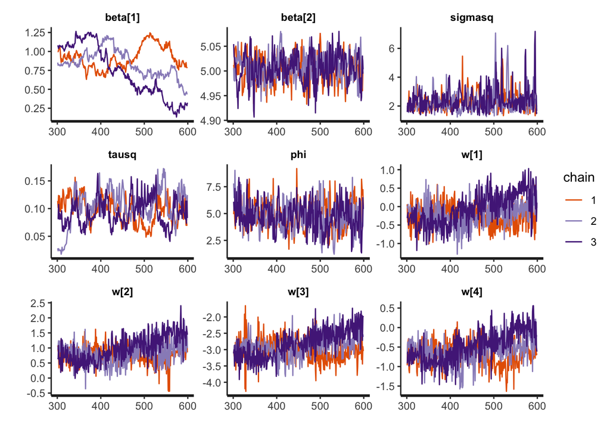

```r
stan_trace(samples_w, pars = c("beta", "sigmasq", "tausq", "phi", "w[1]",
                               "w[2]","w[3]", "w[4]"))
```

It is not surprising to see a slower convergence rate and worse mixing of the MCMC Chains. Response NNGP model marginalizes out the latent process $w$, yields a lower-dimensional parameter space, hence drastically improves the posterior geometry. While the parameters to be estimated in a latent NNGP model $\{\theta, w\}$ are highly correlated, and the number of parameters is on the scale of the number of observations. Thus the convergence rate of MCMC chains from a latent NNGP model is slow because of the high correlation and dimension of the parameter space.

Notice the trace plot of the latent process $w$ over observed locations are highly correlated with the intercept, we modified the code and make the latent process $w(s)$ centered at the intercept. The code of modified latent NNGP model can be found in “nngp.R” and “nngp_latent_b1.stan”. Here we suppress the details of the code and show the results directly:

```r
print(samples_wb1, pars = c("beta", "sigmasq", "tausq", "phi", "w_b1[1]",
                            "w_b1[2]", "w_b1[3]", "w_b1[4]"))
```

```
Inference for Stan model: nngp_latent_b1.
3 chains, each with iter=600; warmup=300; thin=1;
post-warmup draws per chain=300, total post-warmup draws=900.

         mean se_mean   sd  2.5%   25%   50%   75% 97.5% n_eff Rhat
beta[1]  0.76    0.02 0.55 -0.35  0.43  0.79  1.09  1.81  1023 1.00
beta[2]  5.00    0.00 0.03  4.95  4.98  5.00  5.02  5.05   249 1.01
sigmasq  2.51    0.05 0.98  1.43  1.89  2.25  2.80  5.06   437 1.00
tausq    0.10    0.01 0.03  0.02  0.07  0.10  0.11  0.16    19 1.18
phi      4.56    0.09 1.44  1.92  3.56  4.52  5.44  7.42   276 1.01
w_b1[1]  0.68    0.01 0.30  0.07  0.50  0.69  0.88  1.28   680 1.00
w_b1[2]  1.69    0.01 0.30  1.08  1.49  1.70  1.89  2.25   428 1.01
w_b1[3] -2.07    0.01 0.28 -2.59 -2.27 -2.07 -1.88 -1.51  1647 1.00
w_b1[4]  0.24    0.01 0.29 -0.34  0.05  0.26  0.43  0.78  1243 1.00

Samples were drawn using NUTS(diag_e) at Mon Jun  8 22:36:07 2020.
For each parameter, n_eff is a crude measure of effective sample size,
and Rhat is the potential scale reduction factor on split chains (at
convergence, Rhat=1).
```

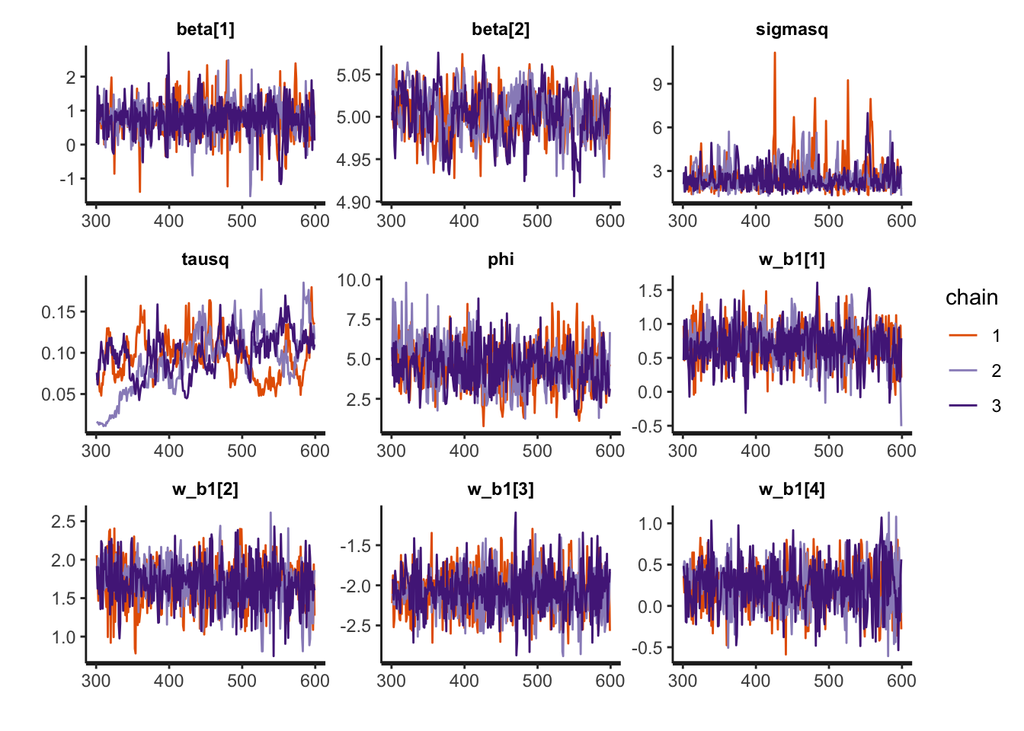

```r
stan_trace(samples_wb1, pars = c("beta", "sigmasq", "tausq", "phi", "w_b1[1]",
                                 "w_b1[2]", "w_b1[3]", "w_b1[4]"))
```

## Discussion

We recommend a response NNGP model for a large scale data analysis when the study focuses on the inference of parameter set $\theta$. On the other hand, latent NNGP models are preferred when the study needs the recovery of latent process $w(s)$. However, the convergence rate of the MCMC Chains from latent model could be prohibitively slow when the dataset is large, so we only recommend coding latent NNGP model in Stan when the dataset is small. For recovering latent process when the dataset is large, package spNNGP provides an algorithm for the latent NNGP model, which implements a sequential Gibbs sampler for updating the latent process. Conjugate NNGP models are also good options for recovering latent process $w(s)$. More details of NNGP based models can be found in Finley et al. (2019)

# SessionInfo and References

## Acknowledgments

I warmly thank Michael Betancourt and Aki Vehtari for useful comments and suggestions, as well as Bob Carpenter and the Stan team for their generous hospitality.

## Licenses

- Code © 2018, Lu Zhang, licensed under [BSD (3-clause)](https://opensource.org/licenses/BSD-3-Clause).
- Text © 2018, Lu Zhang, licensed under [CC-BY NC 4.0](https://creativecommons.org/licenses/by-nc/4.0/).

## References

Datta, A., S. Banerjee, A. O. Finley, and A. E. Gelfand. 2016. “Hierarchical Nearest-Neighbor Gaussian Process Models for Large Geostatistical Datasets.” *Journal of the American Statistical Association* 111: 800–812. http://dx.doi.org/10.1080/01621459.2015.1044091.

Datta, A., S. Banerjee, A. O. Finley, N. A. S. Hamm, and M. Schaap. 2016. “Non-Separable Dynamic Nearest-Neighbor Gaussian Process Models for Large Spatio-Temporal Data with an Application to Particulate Matter Analysis.” *Annals of Applied Statistics* 10: 1286–1316. http://dx.doi.org/10.1214/16-AOAS931.

Finley, Andrew O, Abhirup Datta, Bruce D Cook, Douglas C Morton, Hans E Andersen, and Sudipto Banerjee. 2019. “Efficient Algorithms for Bayesian Nearest Neighbor Gaussian Processes.” *Journal of Computational and Graphical Statistics* 28 (2). Taylor & Francis: 401–14.

Stan Development Team. 2017. “Stan Modeling Language: User’s Guide and Reference Manual.” Version 2.17.

Vecchia, A. V. 1988. “Estimation and Model Identification for Continuous Spatial Processes.” *Journal of the Royal Statistical Society, Series B* 50: 297–312.